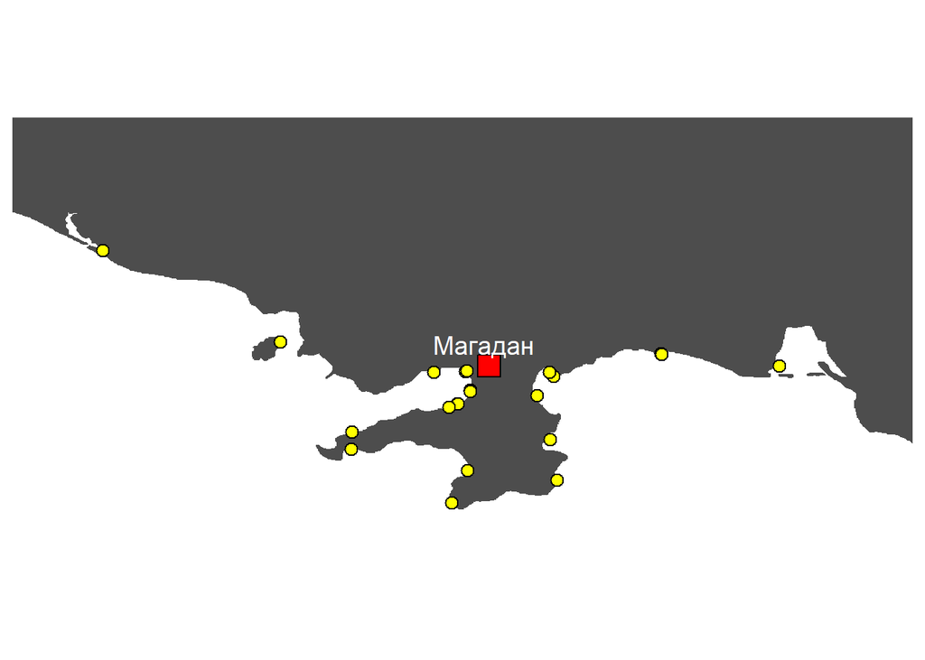

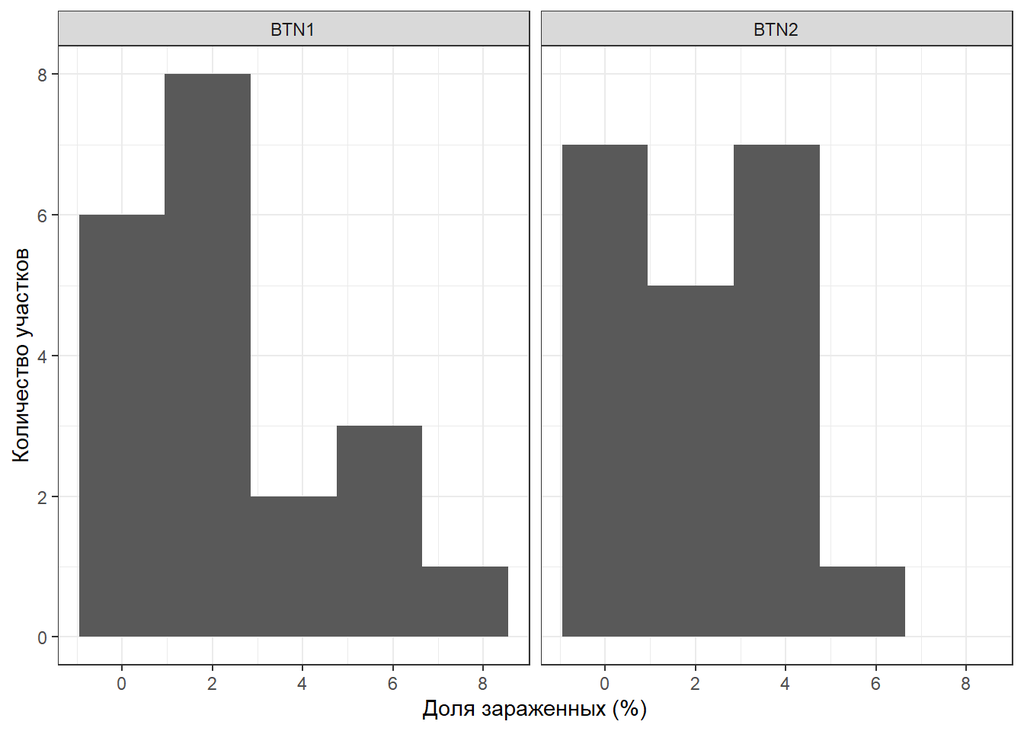

Частота зараженных мидий невелика: единицы процентов в поселении

[figure not shown]

Частота BTN варьирует вдоль побережья

## Новое в обработке данных за 2021, 2023 гг.

Все показатели, которые характеризуют популяционную структуру (кроме OGP, которая про рост) сведены в ОДИН PCA. При этом L3 - L58 это локальное обилие размерных классов в точках взятия проб. Biomass - это биомасса на всем сайте, с учетом проективного покрытия. Перед вычислением PCA все перменные были стандартизованы (средняя = 0, sd = 1), то есть уравнены во вкладах в формирование главных осей.

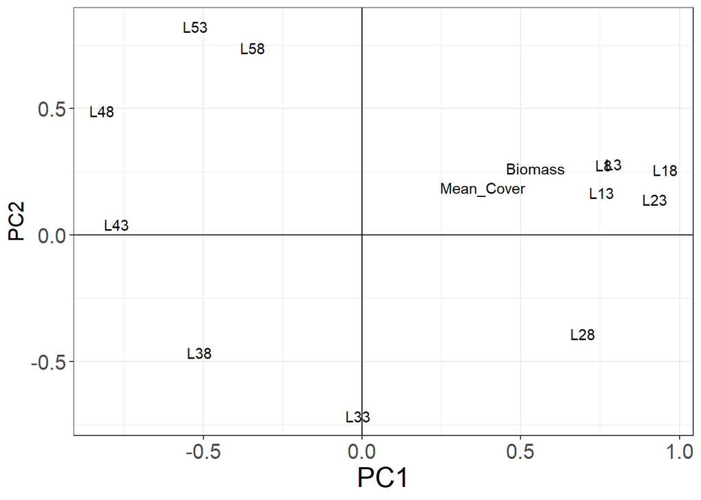

PC1 - это градиент от разреженных банок с доминированием крупных мидий L38-L58 к банкам с большим количеством молоди, высоким покрытием и большой биомассой.

Вот так распределены банки в осях PCA.

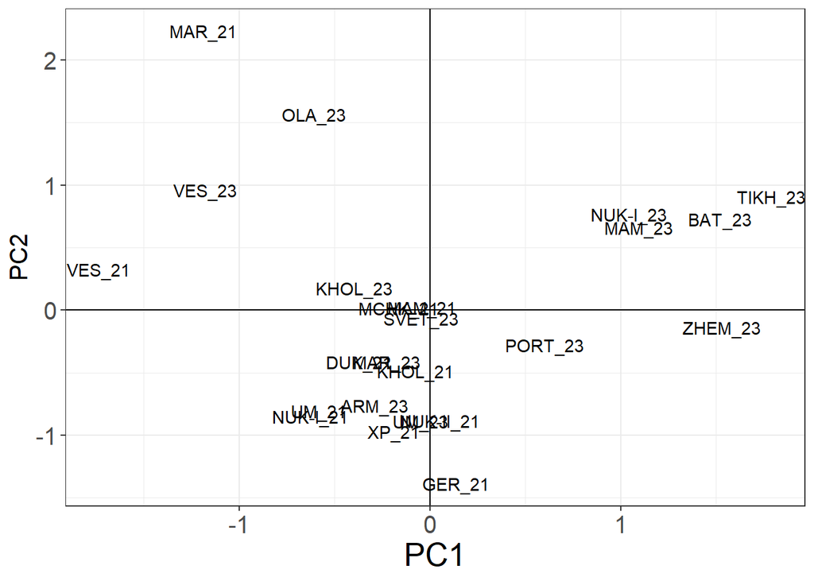

А вот теперь самое интересное. Нарисуем в тех же осях те сайты, которые были пересобраны в 2023 г.

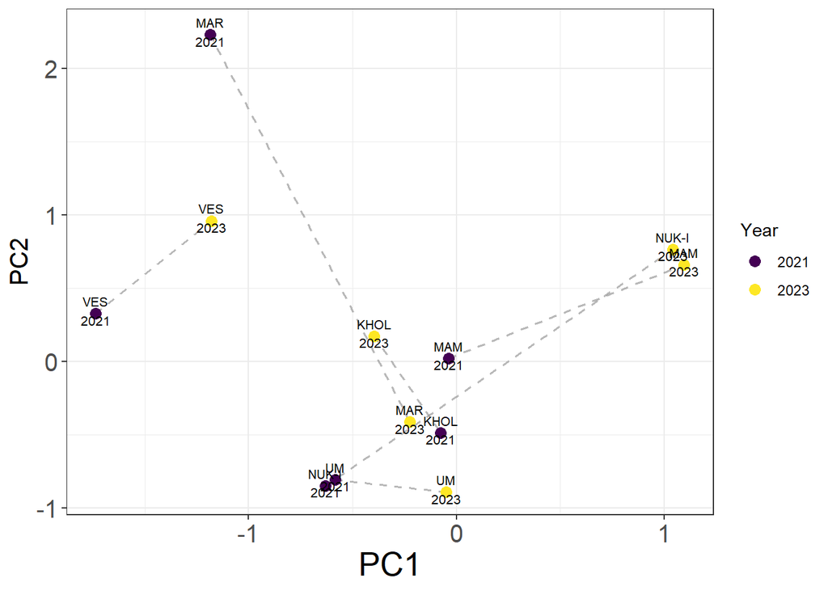

Обрати внимание, что за исключением “Khol”, все сайты сместились слва направо вдоль оси PC1.

Вот для этих же сайтов бокс-плот со значениями PC1 в два разных года.

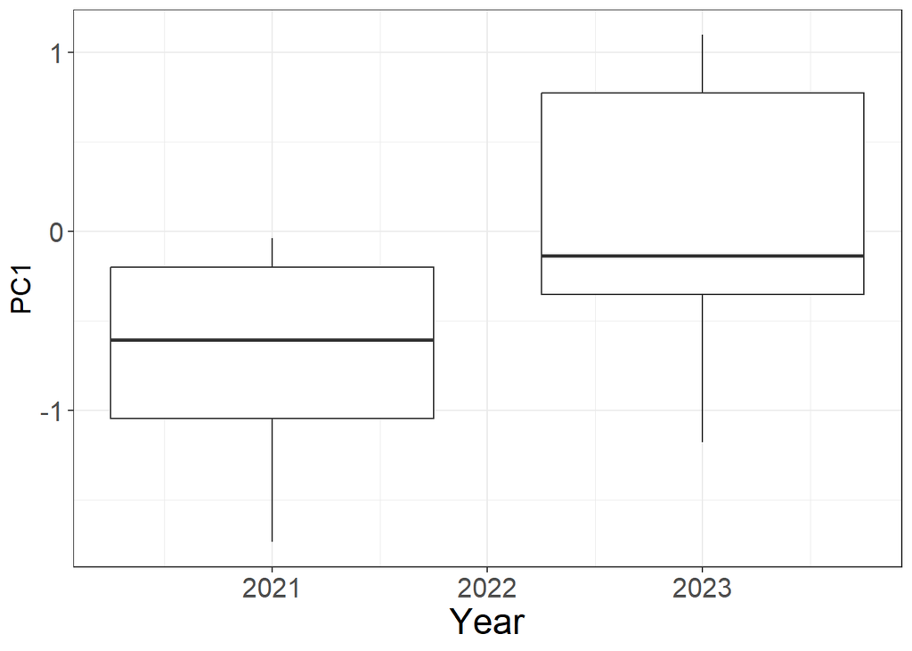

То есть PC1 - это ПРО ДИНАМИКУ. Типа старые банки - переходят в молодые (если уж так не любишь старика Наумова с его циклами, хотя это именно они!).

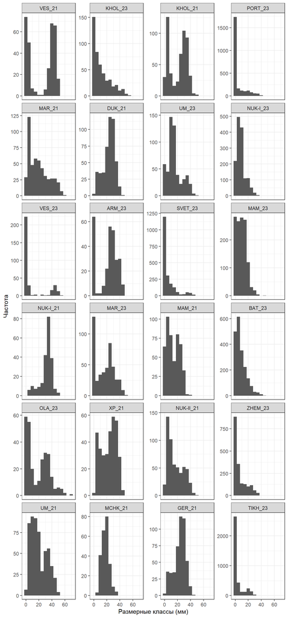

Здесь сайты упорядочены по мере увеличения значения PC1 (вниз по каждой колонке).

Для людей, не желающих здесь видеть циклическую динамику, можно продать идею, что это про градиент от банок с плохим пополнением к банкам с хорошим пополнением.

## “Первичные” данные в градиентах факторов

Здесь приведены иллюстрации о связи “сырых” частот BTN1 и DTN2 с предикторами. Понятно, что где-то связь не выглядит суперской, так как не удалено влияние других предикторов. Ну и я не даю доверительных интервалов так как это совсем уж не корректно.

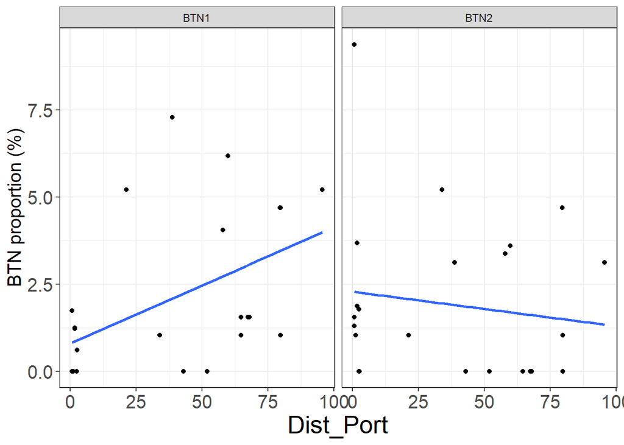

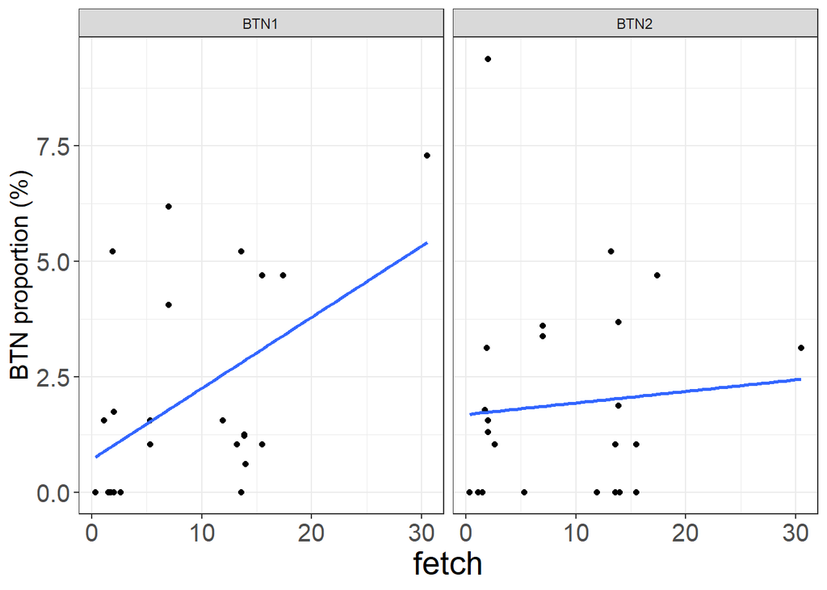

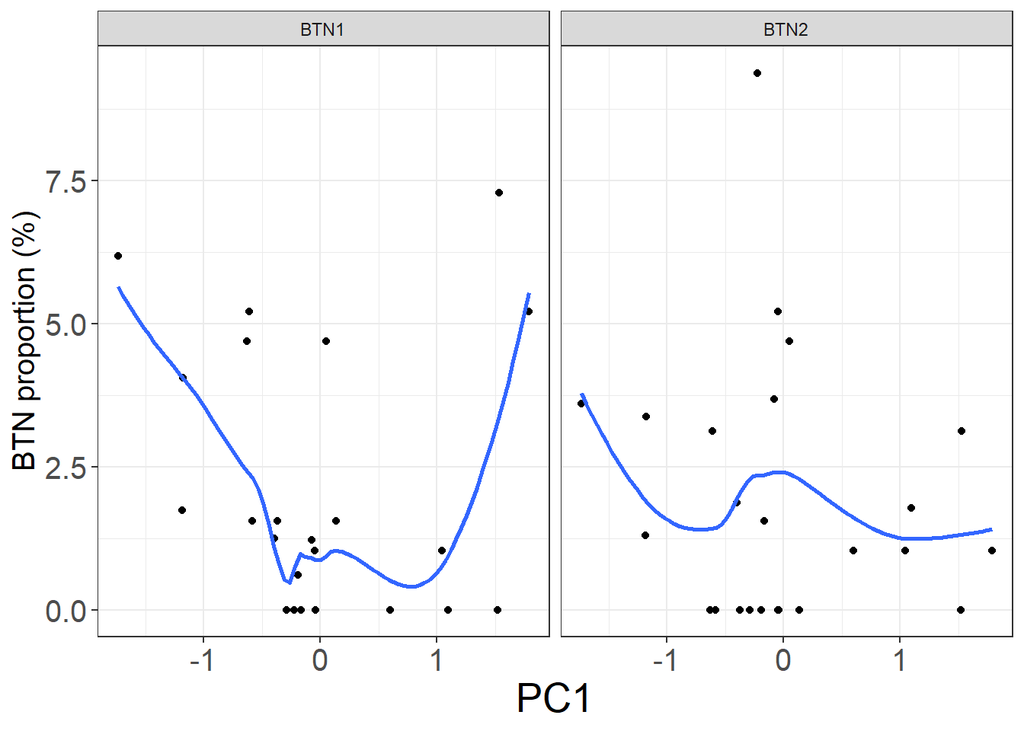

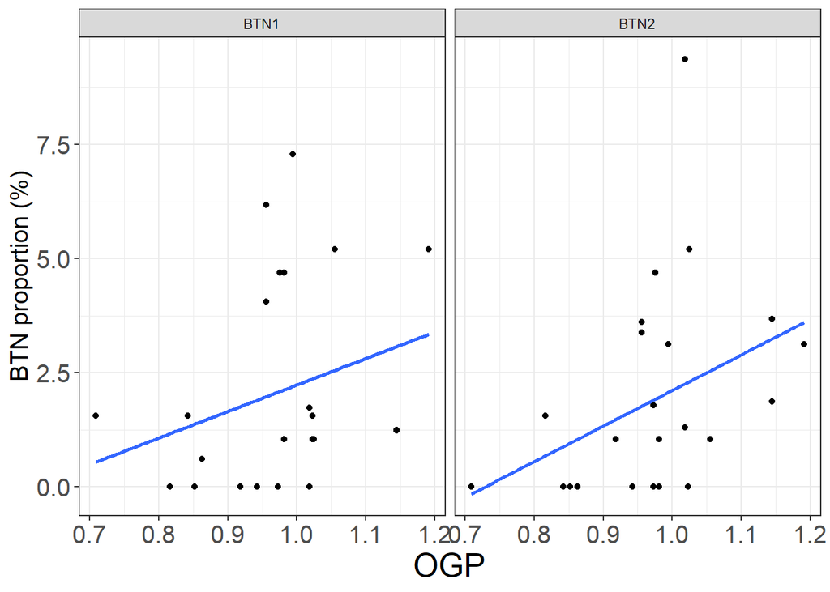

# Модель, отражающая связь зараженности со средовыми предикторами

Это заготовки текста для MM.

All continuous predictors were modeled using cubic regression splines with shrinkage (bs = ‘cs’) to allow for flexible but regularized nonlinear relationships

Generalized Additive Models (GAMs) were fitted using the mgcv package in R. Continuous predictors (distance to port, fetch, principal component 1, and growth proxy) were modeled as smooth terms using cubic regression splines with shrinkage (bs = ‘cs’, k = 5) to allow for flexible but regularized nonlinear relationships. Lineage was included as a fixed factor, and Year/Site as random effects. The binomial family with logit link was used to model cancer incidence. Model fitting used REML for smoothness selection.

### Проверка валидности модели

```
## $uniformity
##
##  Exact one-sample Kolmogorov-Smirnov test
##
## data:  simulationOutput$scaledResiduals
## D = 0.096709, p-value = 0.7239
## alternative hypothesis: two-sided
##
##
## $dispersion
##
##  DHARMa nonparametric dispersion test via sd of residuals fitted vs.
##  simulated
##
## data:  simulationOutput
## dispersion = 1.0353, p-value = 0.7696
## alternative hypothesis: two.sided
##
##
## $outliers
##
##  DHARMa bootstrapped outlier test
##
## data:  simulationOutput
## outliers at both margin(s) = 0, observations = 48, p-value = 1
## alternative hypothesis: two.sided
##  percent confidence interval:
##  0 0
## sample estimates:
## outlier frequency (expected: 0.000208333333333333 )
##                                                   0
```

```
##
##  DHARMa nonparametric dispersion test via sd of residuals fitted vs.
##  simulated
##
## data:  simulationOutput
## dispersion = 1.0353, p-value = 0.7696
## alternative hypothesis: two.sided
```

```
##
## Method: REML   Optimizer: outer newton
## full convergence after 11 iterations.
## Gradient range [-1.076423e-05,7.959083e-06]
## (score 90.23093 & scale 1).
## Hessian positive definite, eigenvalue range [8.905472e-06,2.225294].
## Model rank =  70 / 70
##
## Basis dimension (k) checking results. Low p-value (k-index<1) may
## indicate that k is too low, especially if edf is close to k'.
##
##                                k'      edf k-index p-value
## s(Dist_Port):LineageBTN1 4.00e+00 1.02e+00    1.13    0.97
## s(Dist_Port):LineageBTN2 4.00e+00 2.59e-05    1.13    0.92
## s(fetch):LineageBTN1     4.00e+00 1.01e+00    1.02    0.78
## s(fetch):LineageBTN2     4.00e+00 2.30e-05    1.02    0.69
## s(PC1):LineageBTN1       4.00e+00 1.96e+00    1.11    0.90
## s(PC1):LineageBTN2       4.00e+00 1.36e-01    1.11    0.92
## s(OGP):LineageBTN1       4.00e+00 7.95e-01    1.14    0.94
## s(OGP):LineageBTN2       4.00e+00 1.06e+00    1.14    0.93
## s(Year,Site)             3.60e+01 1.06e+01      NA      NA
```

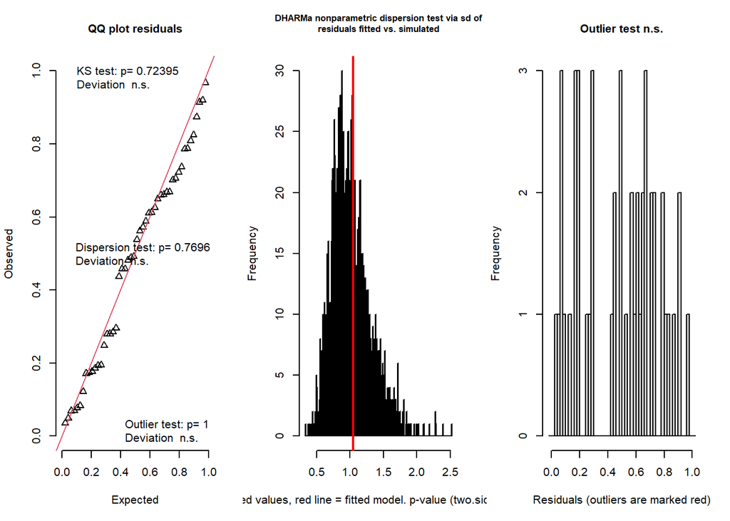

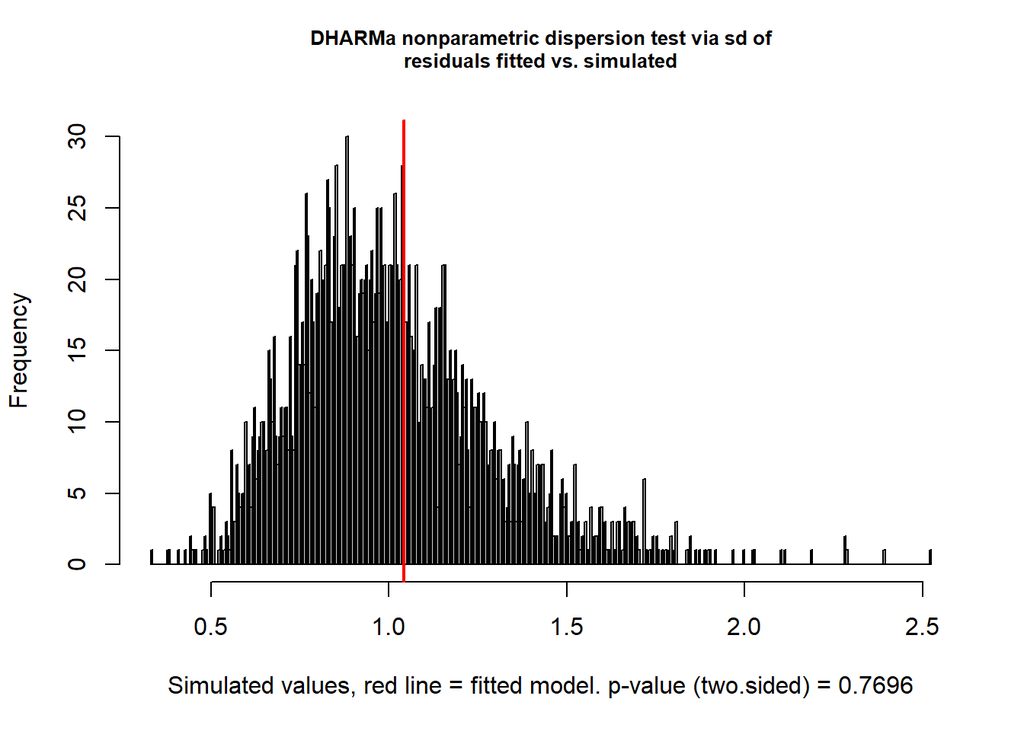

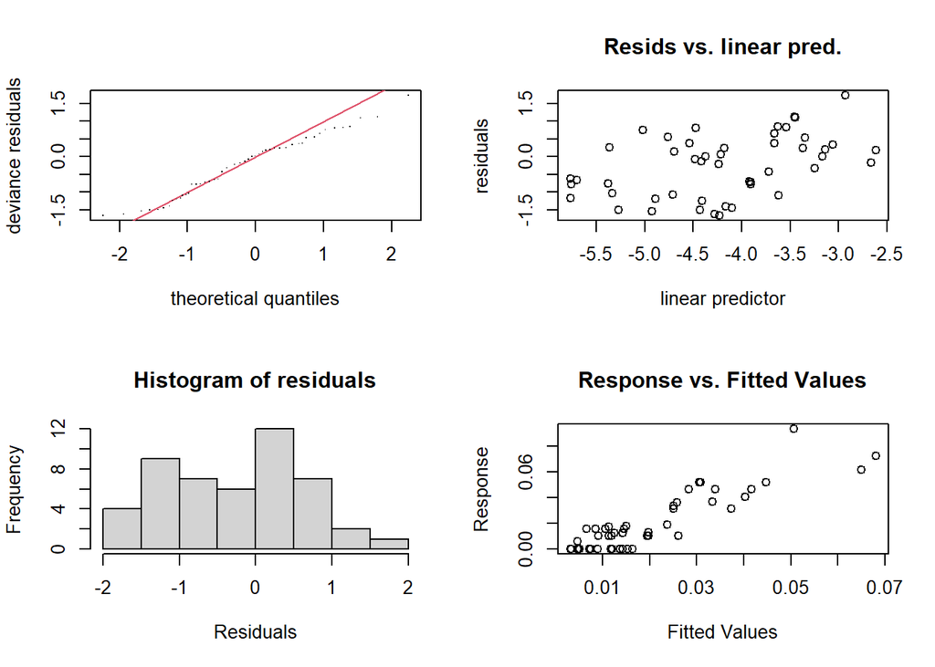

Не супер, но можно принять…

### Результат построения модели

```
##
## Family: binomial
## Link function: logit
##
## Formula:
## cbind(N_cancer, N_helthy) ~ s((Dist_Port), by = Lineage, bs = "cs",
##     k = 5) + s((fetch), by = Lineage, bs = "cs", k = 5) + s((PC1),
##     by = Lineage, bs = "cs", k = 5) + s((OGP), by = Lineage,
##     bs = "cs", k = 5) + Lineage + s(Year, Site, bs = "re")
##
## Parametric coefficients:
##             Estimate Std. Error z value Pr(>|z|)
## (Intercept)  -4.2985     0.2287 -18.793   <2e-16 ***
## LineageBTN2   0.1856     0.2524   0.735    0.462
## ---
## Signif. codes:  0 '***' 0.001 '**' 0.01 '*' 0.05 '.' 0.1 ' ' 1
##
## Approximate significance of smooth terms:
##                                edf Ref.df Chi.sq p-value
## s(Dist_Port):LineageBTN1 1.023e+00      4 13.696 0.00685 **
## s(Dist_Port):LineageBTN2 2.594e-05      4  0.000 0.61002
## s(fetch):LineageBTN1     1.014e+00      4  8.575 0.02738 *
## s(fetch):LineageBTN2     2.297e-05      4  0.000 0.91340
## s(PC1):LineageBTN1       1.961e+00      4 19.934 0.01260 *
## s(PC1):LineageBTN2       1.358e-01      4  0.170 0.30033
## s(OGP):LineageBTN1       7.945e-01      4  3.989 0.05984 .
## s(OGP):LineageBTN2       1.060e+00      4 11.173 0.02364 *
## s(Year,Site)             1.057e+01     23 22.876 0.00162 **
## ---
## Signif. codes:  0 '***' 0.001 '**' 0.01 '*' 0.05 '.' 0.1 ' ' 1
##
## R-sq.(adj) =  0.656   Deviance explained = 71.2%
## -REML = 90.231  Scale est. = 1         n = 48
```

### Визуализация модели

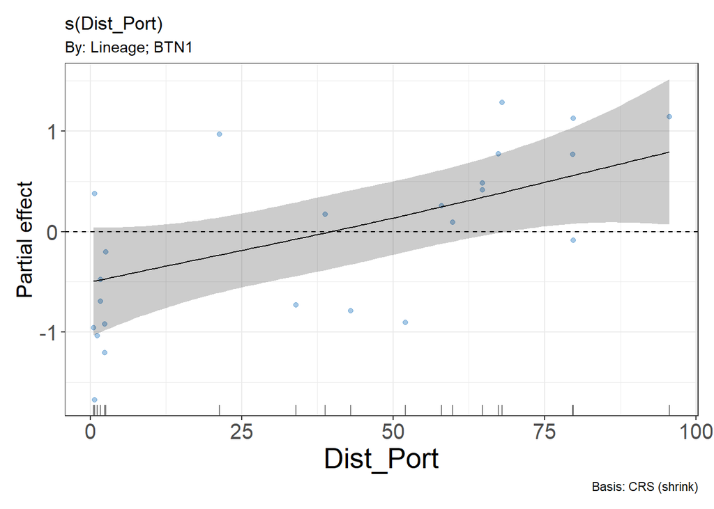

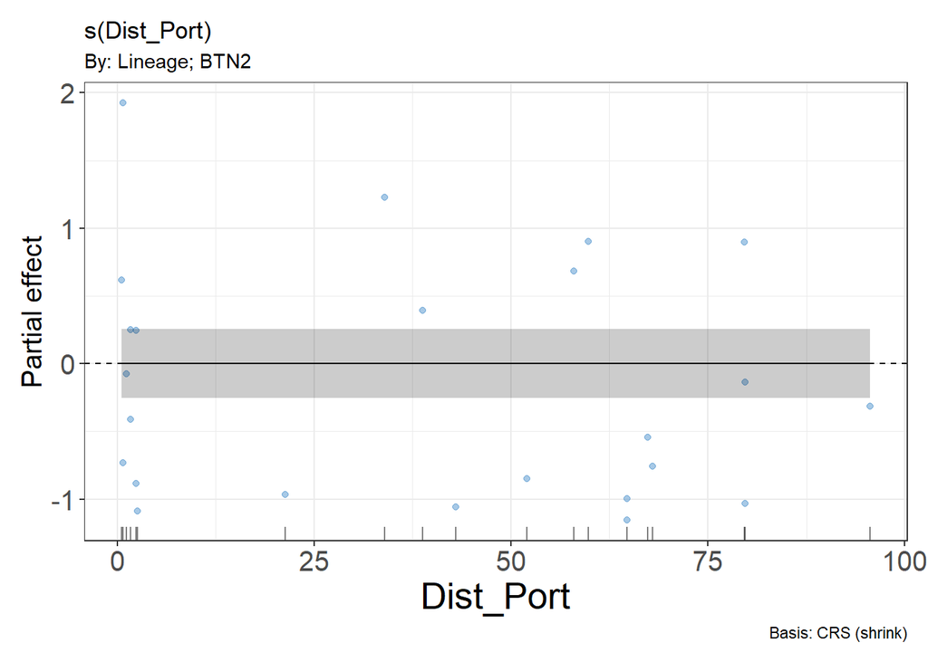

Здесь все как было!

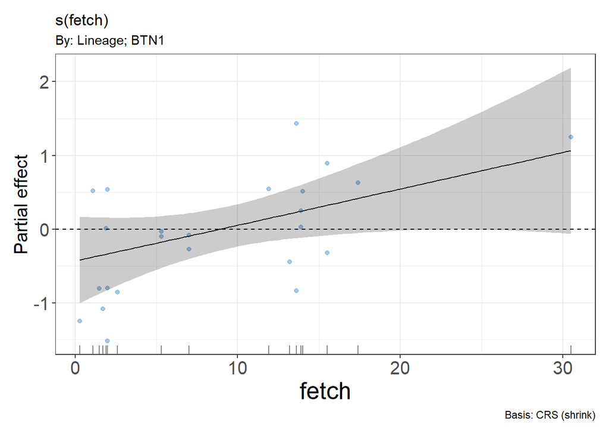

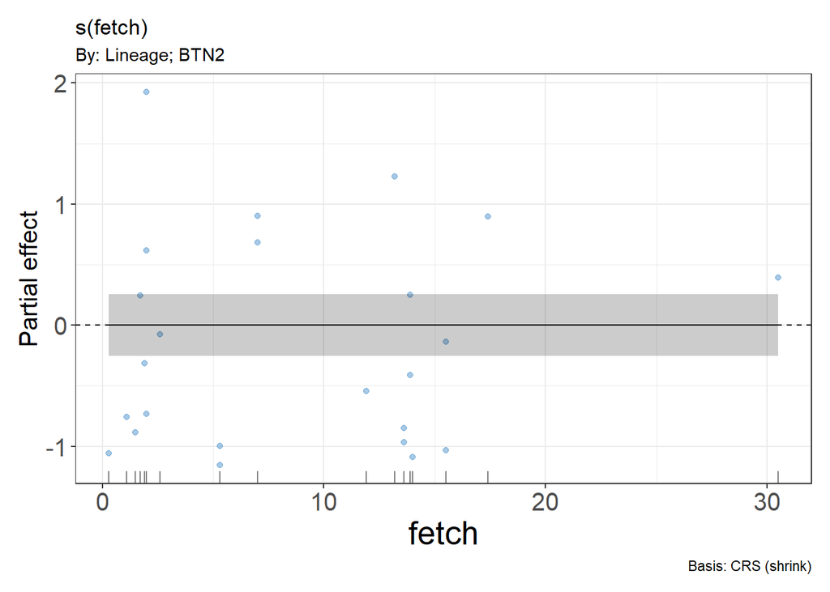

Здесь все как было!

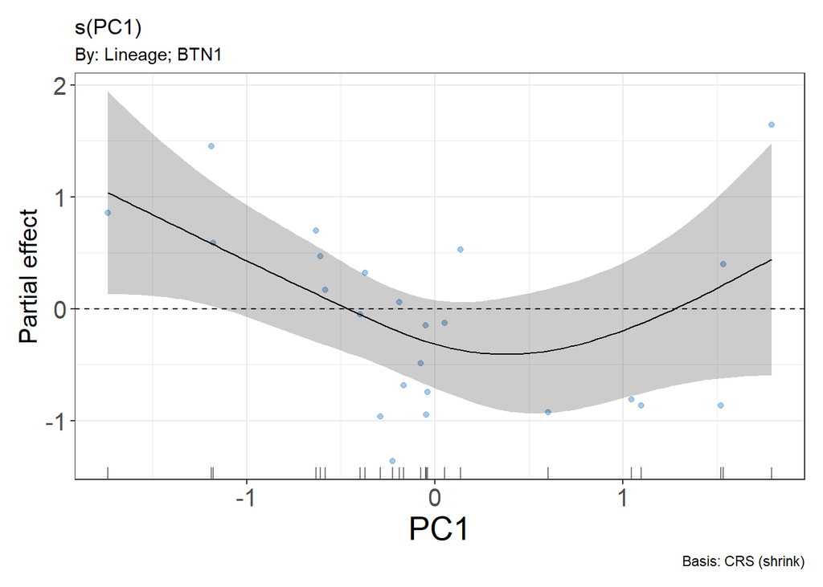

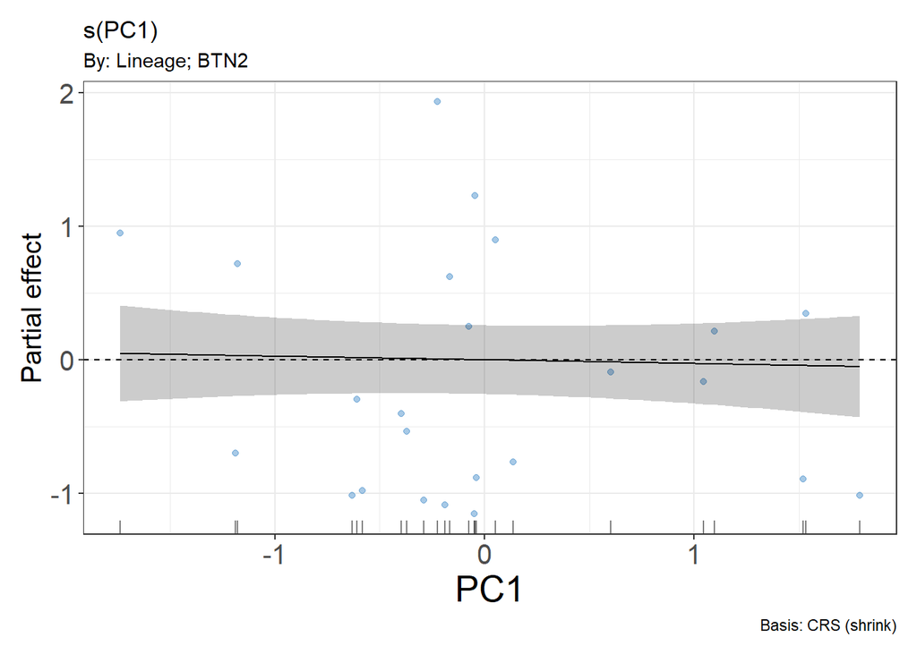

Нелинейность связи BTN1 для меня опять же про циклы, но можно обойтись и без них. Этот график про то, что зараженность BTN1 высокая в левой части градиента PC1, там где старые разреженные банки.

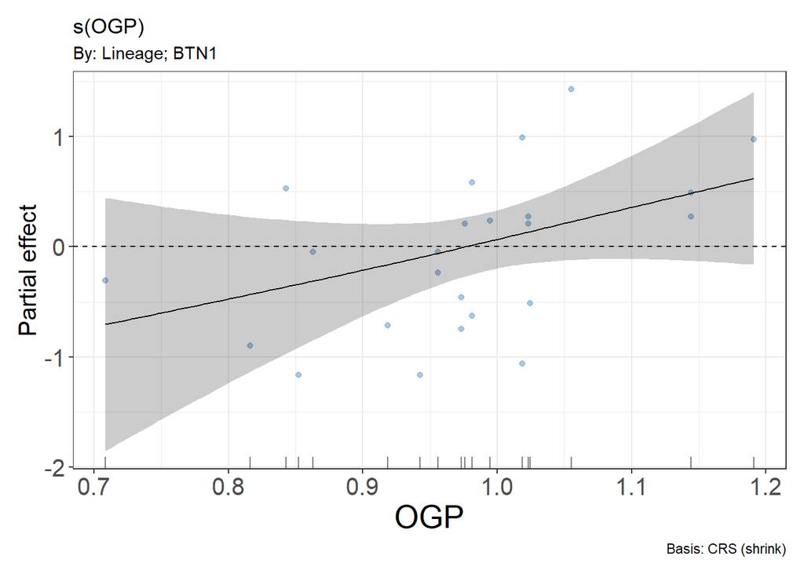

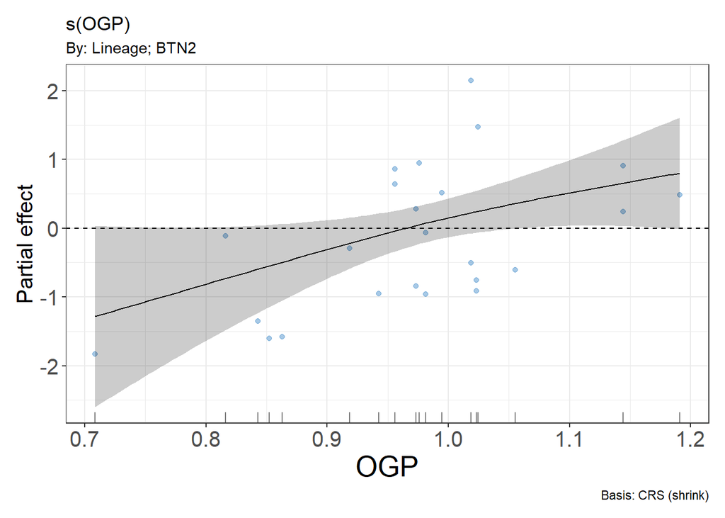

Есть положительная связь с OGP у обеих BTN, хотя значимая только для BTN2. Формально это означает, что если “убрано” (учтено) влияние прочих предикторов, то при прочих равных обе линии себя лучше чувствуют в поселениях, где мидии лучше идет рост. “В здоровом теле здоровый паразит”? Это, возможно, мэтчится с нелюбовью близости к порту, так как антропогенное влияние должно как-то подавлять рост.

Дальше в анализах ничего не менял пока.